# Lab 2

#### 2)

As you can see in the bar chart below, there is a big difference in the number of ratings between all the countries. There is a big difference between the country with the largest number of ratings and the country with the smallest number of ratings.I sorted the locations into least to most ratings per country and did the log function so you can see the difference in numbers clearly.

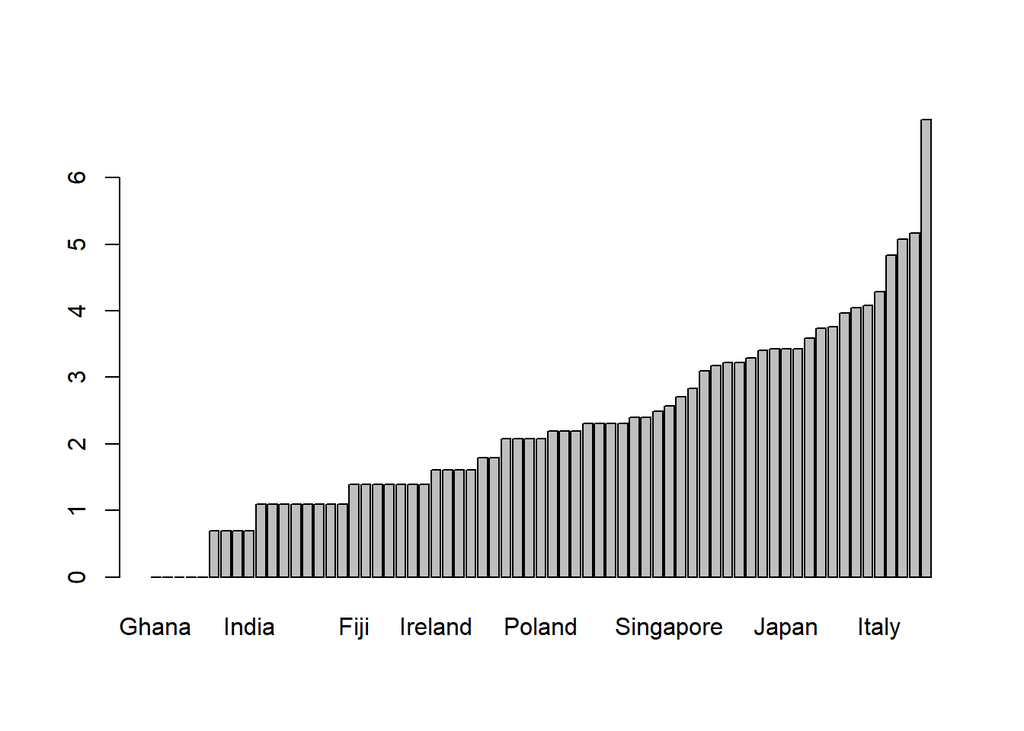

```r
barplot(sort(log(table(choco$Location))))
```

#### 3)

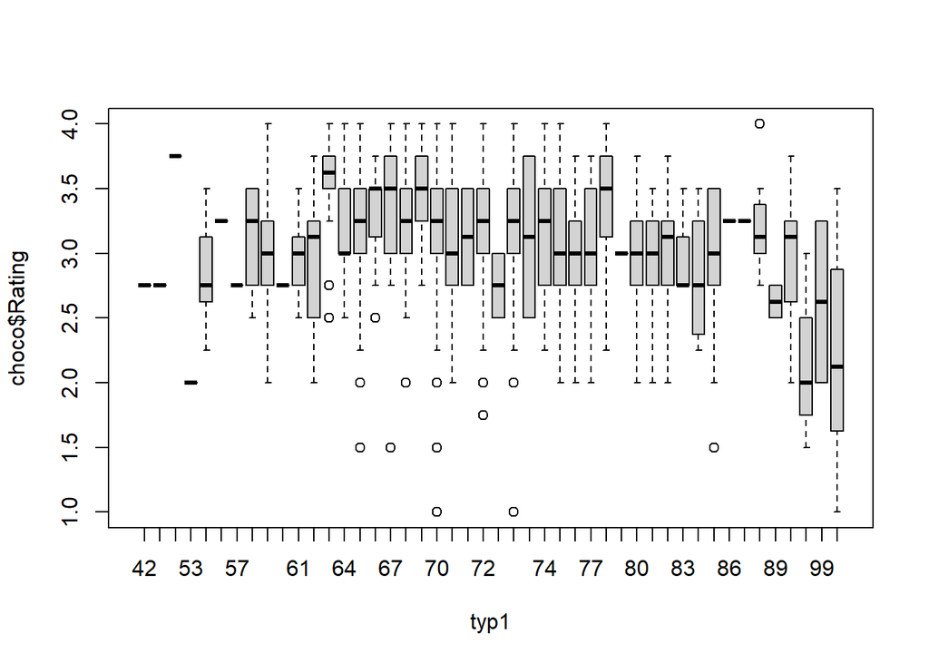

```r
perc <- factor(c(choco$Cocoa_Percent))
lev <- levels(perc)
typ1 <- factor(choco$Cocoa_Percent, levels = lev)
boxplot(choco$Rating ~ typ1)
```

**Correlation:**

```r
cor(choco$Cocoa_Percent, choco$Rating)
```

```
## [1] -0.1510178
```

#### 4)

In order to find how different bean origins compare in terms of flavor I did a few things. First, I reordered bean origin in terms of the mean ratings so I could see how they rank on the different scales of flavor. From this numerical summary I found that Tobago produces beans that make chocolate of a highly recommended flavor, on average. Some other origins that rank further up in flavor are Sao Tome & Principe and Solomon Islands. Some chocolates that were ranked disapointing had beans that were originated from Principe, Puerto Rico, and St. Vincent-Grenadines.The second thing I did was make a boxplot of this information and found that the medians were actually pretty similar throughout the different origins. (sorry I didn’t know how to get rid of all of the origins listed in the beginning before the numerical summary) **Numerical Summary**

```r
re <-reorder(choco$Bean_Origin, choco$Rating, FUN=mean)
re
```

[output not shown]

[output cut: 800 more lines]

**Boxplot**

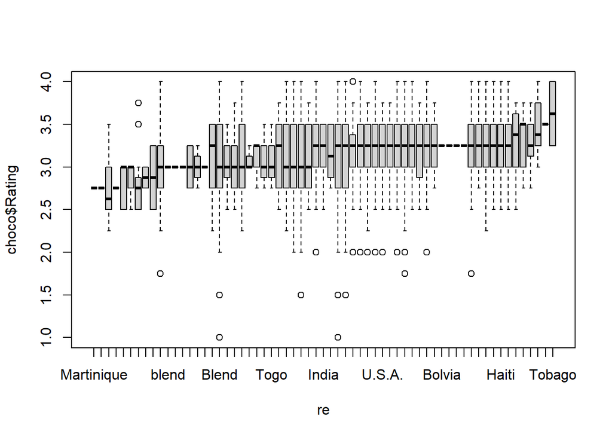

```r
boxplot(choco$Rating ~ re)
```

#### 5)

For the first part of my extra analysis I decided to find the chocolates that were rated as having an unpleasant flavor by sorting out the ones with a ranking between 1 and 1.9 and compare them to chocolates that had an outstanding flavor rating, the ones with a ranking between 4 and 5. I then made a factor out of each of those two groups to find characteristics that showed up the most in them as shown below:

```r
unpleasant <- (choco$Rating >= 1 & choco$Rating <= 1.9)
unpleasantb <- choco[unpleasant, c(3,5,7,10,13)]
summary(factor(unpleasantb$Characteristics2), sort = TRUE, na.rm = TRUE)
```

```
##        astringent            bitter             cocoa dominate off note
##                 1                 2                 1                 1
##             fatty     hint of fruit           intense             musty
##                 1                 1                 1                 1
##              salt   strong chemical strong off flavor       very bitter
##                 1                 2                 1                 2
##              NA's
##                 2
```

```r
outstanding <- (choco$Rating >= 4 & choco$Rating <= 5)
outstandingb <- choco[outstanding, c(3,5,7,10,13)]
summary(factor(outstandingb$Characteristics2), sort = TRUE, na.rm = TRUE)
```

```
##          acidic        balanced          banana           berry    black pepper
##               1               1               1               1               1
##       blueberry    bright fruit   burnt brownie    butterscotch          cherry
##               1               1               1               1               1
##        cinnamon           cocoa         coconut          coffee         complex
##               1               5               2               1               4
##          creamy           dairy      dark berry      deep cocoa  delicate cocoa
##               2               1               1               1               1
##           dense   distinquished     dried fruit           fatty          floral
##               1               1               2               1               2
##           fruit          grassy        hazelnut           homey           honey
##               1               1               1               1               4
##  intense pepper           lemon        licorice            long      mild smoke
##               1               1               1               1               1
##      mild spice            mint        molasses             nut          nutmeg
##               1               1               1               1               1
##            nuts           nutty            pear       pistachio          raisin
##               3               8               1               1               1
##         raisins     raspberries       raspberry       red berry       red fruit
##               1               1               2               1               1
##            rich   roasted cocoa         rounded           spice           spicy
##               2               1               1               1               5
##          sticky      strawberry          subtle           sweet            tart
##               3               1               1               1               1
##     tart citrus        tropical unripened fruit    wild berries            wine
##               1               1               1               1               1
##           woody          yogurt            NA's
##               1               1               4
```

The characteristics that showed up in these two categories make sense especially with bitter and strong chemical showing up in unpleasant. I was surprised that spicy had a lot of occurrences in the outstanding chocolates.

The next analysis I did was create a sub data frame with the highest ranking chocolate, I chose ranking of 3.5 and above. I wanted to find the location and bean origin combination that made the best ranked chocolate. I used a table to find the location with the most occurrences in this data frame and I found the U.S.A. had the most occurrences. From there I filtered out only the rows with U.S.A to look at a table of the bean origins to see which origin had the most occurrences. I concluded that the best chocolates have a company located in the U.S.A. and are made from beans that originate in the Dominican Republic. I also made a barplot representing the occurrences of bean origins of the chocolates made from U.S.A. companies.  
**Here is the table representing the number of best chocolates in each location**

```r
highest_ranked <- choco$Rating >= 3.5
best <- choco[highest_ranked, c(3,5,7,13)]
table(best$Location)
```

```
##
##          Amsterdam          Argentina          Australia            Austria
##                  4                  5                 28                 13
##            Belgium            Bolivia             Brazil             Canada
##                 22                  1                 10                 72
##              Chile           Colombia         Costa Rica     Czech Republic
##                  2                  9                  3                  1
##            Denmark Dominican Republic            Ecuador               Fiji
##                 14                  3                 17                  2
##            Finland             France            Germany          Guatemala
##                  1                 83                 18                  4
##           Honduras            Hungary            Iceland             Israel
##                  2                 10                  2                  6
##              Italy              Japan          Lithuania         Madagascar
##                 32                  9                  2                  6
##             Mexico        Netherlands        New Zealand          Nicaragua
##                  2                  4                 10                  2
##             Norway               Peru        Philippines             Poland
##                  2                  4                  2                  5
##             Russia           Sao Tome           Scotland          Singapore
##                  1                  2                  5                  4
##        South Korea              Spain             Sweden        Switzerland
##                  3                 14                  1                 19
##             Taiwan           Thailand             U.A.E.               U.K.
##                  3                  3                  3                 37
##             U.S.A.          Venezuela            Vietnam
##                349                 10                  9
```

**Here is the table representing the number of best chocolates with different bean origins from companies in the U.S.A.**

```r
loc <- best[best$Location == 'U.S.A.', ]
table(loc$Bean_Origin)
```

```
##
##             Belize              Blend            Bolivia             Brazil
##                 14                 15                 13                 14
##           Colombia         Costa Rica Dominican Republic            Ecuador
##                  5                 10                 48                 39
##               Fiji              Ghana            Grenada          Guatemala
##                  1                  8                  1                 12
##              Haiti           Honduras              India            Jamaica
##                  2                  8                  3                  2
##         Madagascar             Mexico          Nicaragua             Panama
##                 27                  3                 10                  1
##   Papua New Guinea               Peru        Philippines        Puerto Rico
##                  8                 35                  1                  1
##    Solomon Islands           Tanzania           Trinidad             U.S.A.
##                  2                 11                 10                 12
##             Uganda          Venezuela            Vietnam
##                  2                 25                  6
```

**Barplot of occurrences of bean origins of the chocolates made from U.S.A. companies**

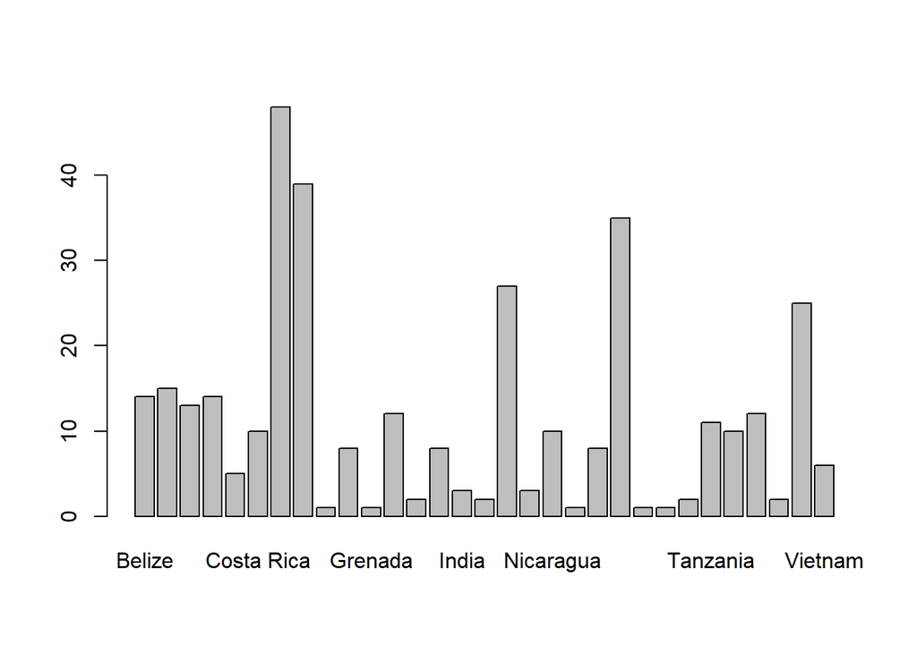

```r
barplot(table(loc$Bean_Origin))
```